# Python Project - (Dataset Exploration Title)

## Introduction

> Introduce the dataset:

This data set contains the customer's data from a fictional loan company - Prosper. This dataset comprises of 113,937 loans with 81 variables on each loan, including loan amount, borrower rate (or interest rate), current loan status, borrower income, and many others.

## Preliminary Wrangling

```python
# import all packages
import numpy as np
import pandas as pd
import matplotlib.pyplot as plt
import seaborn as sns

%matplotlib inline
```

## Introduction

This data set contains the customer's data from a fictional loan company - Prosper. This dataset comprises of 113,937 loans with 81 variables on each loan, including loan amount, borrower rate (or interest rate), current loan status, borrower income, and many others.

```python
# Load our dataset using the pandas read_csv function
df = pd.read_csv('Prosper Loan.csv')
```

```python
df
```

|  | ListingKey | ListingNumber | ListingCreationDate | CreditGrade | Term | LoanStatus | ClosedDate | BorrowerAPR | BorrowerRate | LenderYield | ... | LP_ServiceFees | LP_CollectionFees | LP_GrossPrincipalLoss | LP_NetPrincipalLoss | LP_NonPrincipalRecoverypayments | PercentFunded | Recommendations | InvestmentFromFriendsCount | InvestmentFromFriendsAmount | Investors |
| --- | --- | --- | --- | --- | --- | --- | --- | --- | --- | --- | --- | --- | --- | --- | --- | --- | --- | --- | --- | --- | --- |
| 0 | 1021339766868145413AB3B | 193129 | 09:29.3 | C | 36 | Completed | 14/08/2009 00:00 | 0.16516 | 0.1580 | 0.1380 | ... | -133.18 | 0.0 | 0.0 | 0.0 | 0.0 | 1.0 | 0 | 0 | 0.0 | 258 |
| 1 | 10273602499503308B223C1 | 1209647 | 28:07.9 | NaN | 36 | Current | NaN | 0.12016 | 0.0920 | 0.0820 | ... | 0.00 | 0.0 | 0.0 | 0.0 | 0.0 | 1.0 | 0 | 0 | 0.0 | 1 |
| 2 | 0EE9337825851032864889A | 81716 | 00:47.1 | HR | 36 | Completed | 17/12/2009 00:00 | 0.28269 | 0.2750 | 0.2400 | ... | -24.20 | 0.0 | 0.0 | 0.0 | 0.0 | 1.0 | 0 | 0 | 0.0 | 41 |
| 3 | 0EF5356002482715299901A | 658116 | 02:35.0 | NaN | 36 | Current | NaN | 0.12528 | 0.0974 | 0.0874 | ... | -108.01 | 0.0 | 0.0 | 0.0 | 0.0 | 1.0 | 0 | 0 | 0.0 | 158 |
| 4 | 0F023589499656230C5E3E2 | 909464 | 38:39.1 | NaN | 36 | Current | NaN | 0.24614 | 0.2085 | 0.1985 | ... | -60.27 | 0.0 | 0.0 | 0.0 | 0.0 | 1.0 | 0 | 0 | 0.0 | 20 |
| ... | ... | ... | ... | ... | ... | ... | ... | ... | ... | ... | ... | ... | ... | ... | ... | ... | ... | ... | ... | ... | ... |
| 113932 | E6D9357655724827169606C | 753087 | 55:02.7 | NaN | 36 | Current | NaN | 0.22354 | 0.1864 | 0.1764 | ... | -75.58 | 0.0 | 0.0 | 0.0 | 0.0 | 1.0 | 0 | 0 | 0.0 | 1 |
| 113933 | E6DB353036033497292EE43 | 537216 | 42:55.3 | NaN | 36 | FinalPaymentInProgress | NaN | 0.13220 | 0.1110 | 0.1010 | ... | -30.05 | 0.0 | 0.0 | 0.0 | 0.0 | 1.0 | 0 | 0 | 0.0 | 22 |
| 113934 | E6E13596170052029692BB1 | 1069178 | 49:12.7 | NaN | 60 | Current | NaN | 0.23984 | 0.2150 | 0.2050 | ... | -16.91 | 0.0 | 0.0 | 0.0 | 0.0 | 1.0 | 0 | 0 | 0.0 | 119 |
| 113935 | E6EB3531504622671970D9E | 539056 | 18:26.6 | NaN | 60 | Completed | 13/08/2013 00:00 | 0.28408 | 0.2605 | 0.2505 | ... | -235.05 | 0.0 | 0.0 | 0.0 | 0.0 | 1.0 | 0 | 0 | 0.0 | 274 |
| 113936 | E6ED3600409833199F711B7 | 1140093 | 27:37.7 | NaN | 36 | Current | NaN | 0.13189 | 0.1039 | 0.0939 | ... | -1.70 | 0.0 | 0.0 | 0.0 | 0.0 | 1.0 | 0 | 0 | 0.0 | 1 |

113937 rows × 81 columns

```python
# Access the dataset to gain understanding of its structure and variables
print(df.shape)
```

```
(113937, 81)
```

```python
df.head()
```

|  | ListingKey | ListingNumber | ListingCreationDate | CreditGrade | Term | LoanStatus | ClosedDate | BorrowerAPR | BorrowerRate | LenderYield | ... | LP_ServiceFees | LP_CollectionFees | LP_GrossPrincipalLoss | LP_NetPrincipalLoss | LP_NonPrincipalRecoverypayments | PercentFunded | Recommendations | InvestmentFromFriendsCount | InvestmentFromFriendsAmount | Investors |
| --- | --- | --- | --- | --- | --- | --- | --- | --- | --- | --- | --- | --- | --- | --- | --- | --- | --- | --- | --- | --- | --- |
| 0 | 1021339766868145413AB3B | 193129 | 09:29.3 | C | 36 | Completed | 14/08/2009 00:00 | 0.16516 | 0.1580 | 0.1380 | ... | -133.18 | 0.0 | 0.0 | 0.0 | 0.0 | 1.0 | 0 | 0 | 0.0 | 258 |
| 1 | 10273602499503308B223C1 | 1209647 | 28:07.9 | NaN | 36 | Current | NaN | 0.12016 | 0.0920 | 0.0820 | ... | 0.00 | 0.0 | 0.0 | 0.0 | 0.0 | 1.0 | 0 | 0 | 0.0 | 1 |
| 2 | 0EE9337825851032864889A | 81716 | 00:47.1 | HR | 36 | Completed | 17/12/2009 00:00 | 0.28269 | 0.2750 | 0.2400 | ... | -24.20 | 0.0 | 0.0 | 0.0 | 0.0 | 1.0 | 0 | 0 | 0.0 | 41 |
| 3 | 0EF5356002482715299901A | 658116 | 02:35.0 | NaN | 36 | Current | NaN | 0.12528 | 0.0974 | 0.0874 | ... | -108.01 | 0.0 | 0.0 | 0.0 | 0.0 | 1.0 | 0 | 0 | 0.0 | 158 |
| 4 | 0F023589499656230C5E3E2 | 909464 | 38:39.1 | NaN | 36 | Current | NaN | 0.24614 | 0.2085 | 0.1985 | ... | -60.27 | 0.0 | 0.0 | 0.0 | 0.0 | 1.0 | 0 | 0 | 0.0 | 20 |

5 rows × 81 columns

```python
df.info
```

[output not shown]

[output cut: 64 more lines]

```python
# Create a new dataset with only variables of interest
new_df = df.iloc[:,[2,4,5,7,8,9,16,19,20,21,47,48,49,63,64,65,67]]
new_df.head(10)
```

|  | ListingCreationDate | Term | LoanStatus | BorrowerAPR | BorrowerRate | LenderYield | ListingCategory (numeric) | EmploymentStatus | EmploymentStatusDuration | IsBorrowerHomeowner | IncomeRange | IncomeVerifiable | StatedMonthlyIncome | LoanOriginalAmount | LoanOriginationDate | LoanOriginationQuarter | MonthlyLoanPayment |
| --- | --- | --- | --- | --- | --- | --- | --- | --- | --- | --- | --- | --- | --- | --- | --- | --- | --- |
| 0 | 09:29.3 | 36 | Completed | 0.16516 | 0.1580 | 0.1380 | 0 | Self-employed | 2.0 | True | $25,000-49,999 | True | 3083.333333 | 9425 | 12/09/2007 00:00 | Q3 2007 | 330.43 |
| 1 | 28:07.9 | 36 | Current | 0.12016 | 0.0920 | 0.0820 | 2 | Employed | 44.0 | False | $50,000-74,999 | True | 6125.000000 | 10000 | 03/03/2014 00:00 | Q1 2014 | 318.93 |
| 2 | 00:47.1 | 36 | Completed | 0.28269 | 0.2750 | 0.2400 | 0 | Not available | NaN | False | Not displayed | True | 2083.333333 | 3001 | 17/01/2007 00:00 | Q1 2007 | 123.32 |
| 3 | 02:35.0 | 36 | Current | 0.12528 | 0.0974 | 0.0874 | 16 | Employed | 113.0 | True | $25,000-49,999 | True | 2875.000000 | 10000 | 01/11/2012 00:00 | Q4 2012 | 321.45 |
| 4 | 38:39.1 | 36 | Current | 0.24614 | 0.2085 | 0.1985 | 2 | Employed | 44.0 | True | $100,000+ | True | 9583.333333 | 15000 | 20/09/2013 00:00 | Q3 2013 | 563.97 |
| 5 | 26:37.1 | 60 | Current | 0.15425 | 0.1314 | 0.1214 | 1 | Employed | 82.0 | True | $100,000+ | True | 8333.333333 | 15000 | 24/12/2013 00:00 | Q4 2013 | 342.37 |
| 6 | 52:56.1 | 36 | Current | 0.31032 | 0.2712 | 0.2612 | 1 | Employed | 172.0 | False | $25,000-49,999 | True | 2083.333333 | 3000 | 18/04/2013 00:00 | Q2 2013 | 122.67 |
| 7 | 49:27.5 | 36 | Current | 0.23939 | 0.2019 | 0.1919 | 2 | Employed | 103.0 | False | $25,000-49,999 | True | 3355.750000 | 10000 | 13/05/2013 00:00 | Q2 2013 | 372.60 |
| 8 | 43:39.1 | 36 | Current | 0.07620 | 0.0629 | 0.0529 | 7 | Employed | 269.0 | True | $25,000-49,999 | True | 3333.333333 | 10000 | 12/12/2013 00:00 | Q4 2013 | 305.54 |
| 9 | 43:39.1 | 36 | Current | 0.07620 | 0.0629 | 0.0529 | 7 | Employed | 269.0 | True | $25,000-49,999 | True | 3333.333333 | 10000 | 12/12/2013 00:00 | Q4 2013 | 305.54 |

```python
# Drop missing values in dataset
new_df.dropna(inplace=True)
```

```
C:\Users\HP 840 G3\AppData\Local\Temp\ipykernel_1056\1381821011.py:2: SettingWithCopyWarning:
A value is trying to be set on a copy of a slice from a DataFrame

See the caveats in the documentation: https://pandas.pydata.org/pandas-docs/stable/user_guide/indexing.html#returning-a-view-versus-a-copy
  new_df.dropna(inplace=True)
```

```python
#view the structure of the new dataset
new_df.info
```

[output not shown]

[output cut: 51 more lines]

Data Cleaning

EmploymentStatusDuration to be converted to integer

ListCategory (Numeric) to be renamed to ListCategory and its numeric values replaced with categorical values.

ListingCreationDate and LoanOriginationDate to be converted to datetime datatype.

LoanStatus, ListingCategory, EmploymentStatus, IncomeRange, LoanOriginationQuarter to be converted to category

datatype.

Reorder the IncomeRange categories to be in a set order.

```python
# statistical analysis of numerical variables
new_df.describe()
```

|  | Term | BorrowerAPR | BorrowerRate | LenderYield | ListingCategory (numeric) | EmploymentStatusDuration | StatedMonthlyIncome | LoanOriginalAmount | MonthlyLoanPayment |
| --- | --- | --- | --- | --- | --- | --- | --- | --- | --- |
| count | 106312.000000 | 106312.000000 | 106312.000000 | 106312.000000 | 106312.000000 | 106312.000000 | 1.063120e+05 | 106312.000000 | 106312.000000 |
| mean | 41.176236 | 0.220227 | 0.192979 | 0.182856 | 2.972458 | 96.071582 | 5.670567e+03 | 8566.440693 | 279.018561 |
| std | 10.720386 | 0.080909 | 0.075207 | 0.074977 | 4.065188 | 94.480605 | 7.607363e+03 | 6266.438890 | 192.185767 |
| min | 12.000000 | 0.006530 | 0.000000 | -0.010000 | 0.000000 | 0.000000 | 0.000000e+00 | 1000.000000 | 0.000000 |
| 25% | 36.000000 | 0.157130 | 0.133400 | 0.123400 | 1.000000 | 26.000000 | 3.330167e+03 | 4000.000000 | 138.840000 |
| 50% | 36.000000 | 0.210260 | 0.183100 | 0.172900 | 1.000000 | 67.000000 | 4.750000e+03 | 7000.000000 | 229.170000 |
| 75% | 36.000000 | 0.285740 | 0.251100 | 0.240600 | 3.000000 | 137.000000 | 6.916667e+03 | 12000.000000 | 377.640000 |
| max | 60.000000 | 0.423950 | 0.360000 | 0.340000 | 20.000000 | 755.000000 | 1.750003e+06 | 35000.000000 | 2251.510000 |

```python
# convert EmploymentStatusDuration column to an integer data type
new_df['EmploymentStatusDuration'] = new_df['EmploymentStatusDuration'].astype(int)
new_df['EmploymentStatusDuration'].dtype
```

```
C:\Users\HP 840 G3\AppData\Local\Temp\ipykernel_1056\809629624.py:2: SettingWithCopyWarning:
A value is trying to be set on a copy of a slice from a DataFrame.
Try using .loc[row_indexer,col_indexer] = value instead

See the caveats in the documentation: https://pandas.pydata.org/pandas-docs/stable/user_guide/indexing.html#returning-a-view-versus-a-copy
  new_df['EmploymentStatusDuration'] = new_df['EmploymentStatusDuration'].astype(int)
```

```
dtype('int32')
```

```python
# Rename column name for the ListCategory (numeric) variable
new_df = new_df.rename(columns={'ListingCategory (numeric)':'ListingCategory'})
new_df.info()
```

```
<class 'pandas.core.frame.DataFrame'>
Int64Index: 106312 entries, 0 to 113936
Data columns (total 17 columns):
 #   Column                    Non-Null Count   Dtype
---  ------                    --------------   -----
 0   ListingCreationDate       106312 non-null  object
 1   Term                      106312 non-null  int64
 2   LoanStatus                106312 non-null  object
 3   BorrowerAPR               106312 non-null  float64
 4   BorrowerRate              106312 non-null  float64
 5   LenderYield               106312 non-null  float64
 6   ListingCategory           106312 non-null  int64
 7   EmploymentStatus          106312 non-null  object
 8   EmploymentStatusDuration  106312 non-null  int32
 9   IsBorrowerHomeowner       106312 non-null  bool
 10  IncomeRange               106312 non-null  object
 11  IncomeVerifiable          106312 non-null  bool
 12  StatedMonthlyIncome       106312 non-null  float64
 13  LoanOriginalAmount        106312 non-null  int64
 14  LoanOriginationDate       106312 non-null  object
 15  LoanOriginationQuarter    106312 non-null  object
 16  MonthlyLoanPayment        106312 non-null  float64
dtypes: bool(2), float64(5), int32(1), int64(3), object(6)
memory usage: 12.8+ MB
```

```python
# convert the variables (ListingCreationDate and LoanOriginationDate) to datetime datatype.

new_df['ListingCreationDate'] = pd.to_datetime(df['ListingCreationDate'], errors='coerce')
new_df['LoanOriginationDate'] = pd.to_datetime(df['LoanOriginationDate'], errors='coerce')
new_df.info()
```

```
<class 'pandas.core.frame.DataFrame'>
Int64Index: 106312 entries, 0 to 113936
Data columns (total 17 columns):
 #   Column                    Non-Null Count   Dtype
---  ------                    --------------   -----
 0   ListingCreationDate       42377 non-null   datetime64[ns]
 1   Term                      106312 non-null  int64
 2   LoanStatus                106312 non-null  object
 3   BorrowerAPR               106312 non-null  float64
 4   BorrowerRate              106312 non-null  float64
 5   LenderYield               106312 non-null  float64
 6   ListingCategory           106312 non-null  int64
 7   EmploymentStatus          106312 non-null  object
 8   EmploymentStatusDuration  106312 non-null  int32
 9   IsBorrowerHomeowner       106312 non-null  bool
 10  IncomeRange               106312 non-null  object
 11  IncomeVerifiable          106312 non-null  bool
 12  StatedMonthlyIncome       106312 non-null  float64
 13  LoanOriginalAmount        106312 non-null  int64
 14  LoanOriginationDate       106312 non-null  datetime64[ns]
 15  LoanOriginationQuarter    106312 non-null  object
 16  MonthlyLoanPayment        106312 non-null  float64
dtypes: bool(2), datetime64[ns](2), float64(5), int32(1), int64(3), object(4)
memory usage: 12.8+ MB
```

```python
# change all numeric values in ListingCategory column to their associated categorical values

new_df['ListingCategory'] = new_df['ListingCategory'].map({0:'Not Available', 1:'Debt Consolidation', 2:'Home Improvement', 3:'Business', 4:'Personal Loan', 5:'Student Use', 6:'Auto', 7:'Other', 8:'Baby&Adoption', 9:'Boat', 10: 'Cosmetic Procedure', 11:'Engagement Ring', 12:'Green Loans', 13:'Household Expenses', 14:'Large Purchases', 15:'Medical/Dental', 16:'Motorcycle', 17:'RV', 18:'Taxes', 19:'Vacation', 20:'Wedding Loans'})
new_df['ListingCategory'].value_counts()
```

```
Debt Consolidation    58293
Other                 10491
Not Available          9363
Home Improvement       7432
Business               7187
Auto                   2572
Personal Loan          2395
Household Expenses     1995
Medical/Dental         1522
Taxes                   885
Large Purchases         876
Wedding Loans           770
Vacation                768
Student Use             756
Motorcycle              304
Engagement Ring         217
Baby&Adoption           199
Cosmetic Procedure       91
Boat                     85
Green Loans              59
RV                       52
Name: ListingCategory, dtype: int64
```

```python
# Convert LoanStatus, ListingCategory, EmploymentStatus, IncomeRange, LoanOriginationQuarter to category datatype and order the categories

new_df['LoanStatus'] = new_df['LoanStatus'].astype('category')
new_df['ListingCategory'] = new_df['ListingCategory'].astype('category')
new_df['EmploymentStatus'] = new_df['EmploymentStatus'].astype('category')
new_df['IncomeRange'] = new_df['IncomeRange'].astype('category')
new_df['LoanOriginationQuarter'] = new_df['LoanOriginationQuarter'].astype('category')
```

```python
#Check existing order of the IncomeRange categories

new_df.IncomeRange
```

```
0         $25,000-49,999
1         $50,000-74,999
3         $25,000-49,999
4              $100,000+
5              $100,000+
               ...
113932    $50,000-74,999
113933    $75,000-99,999
113934    $25,000-49,999
113935    $25,000-49,999
113936    $50,000-74,999
Name: IncomeRange, Length: 106312, dtype: category
Categories (8, object): ['$0', '$1-24,999', '$100,000+', '$25,000-49,999', '$50,000-74,999', '$75,000-99,999', 'Not displayed', 'Not employed']
```

```python
# Set the order of the IncomeRange categorical variable

from pandas.api.types import CategoricalDtype
income_range_cat = ['Not displayed', 'Not employed','$0', '$1-24,999', '$25,000-49,999', '$50,000-74,999', '$75,000-99,999','$100,000+']
ord_cat = CategoricalDtype(categories=income_range_cat, ordered=True)
new_df.IncomeRange = new_df.IncomeRange.astype(ord_cat)
```

```python
# confirm if order is set as assigned
new_df.IncomeRange
```

```
0         $25,000-49,999
1         $50,000-74,999
3         $25,000-49,999
4              $100,000+
5              $100,000+
               ...
113932    $50,000-74,999
113933    $75,000-99,999
113934    $25,000-49,999
113935    $25,000-49,999
113936    $50,000-74,999
Name: IncomeRange, Length: 106312, dtype: category
Categories (8, object): ['Not displayed' < 'Not employed' < '$0' < '$1-24,999' < '$25,000-49,999' < '$50,000-74,999' < '$75,000-99,999' < '$100,000+']
```

### What is the structure of your dataset?

The Prosper dataset contains 113937 observations and 81 variables. Out of these 81 variables, the analysis would be focused on just 17 variables of interest to help with answering the research questions. A new dataset with the variables of interest was created with a structure of 106312 observations and 17 features. The loan dataset includes nine categorical variables comprising of : ListingCreationDate, LoanStatus, ListingCategory, EmploymentStatus, IsBorrowerHomeowner, IncomeRange, IncomeVerifiable, LoanOriginationDate, LoanOriginationQuarter and eight quantitative variables comprising of : Term, BorrowerAPR, BorrowerRate, LenderYield, EmploymentStatusDuration, StatedMonthlyIncome, LoanOriginalAmount, MonthlyLoanPayment.

### What is/are the main feature(s) of interest in your dataset?

The main features of interest from the prosper dataset are - factors that affect a loan's outcome status, factors that affects the borrower's APR or interest rate, and ascertaining if there are differences between loans depending on how large the original loan amount was?

### What features in the dataset do you think will help support your investigation into your feature(s) of interest?

The LoanStatus, BorrowerAPR, BorrowerRate, LoanOriginalAmount are the main features in the dataset that i expect that upon investigation with other variables would give rise to the insights needed from the data. However, I think that the ListingCategory, IncomeRange, StatedMonthlyIncome, EmploymentStatus and IsBorrowerHomeOwner will have an effect on how large the original loan is as I think these are the main factors that can either help or hinder someone from getting a loan.I also think the EmploymentStatus, ImcomeRange and StatedMonthlyIncome will have an effect on the LoanStatus as i think employed persons would have the financial bandwidth to repay their loans in due time as compared to an unemployed or low income earner.

## Univariate Exploration

Firstly, I'll start by looking at the first variable of interest - Borrower's Annual Percentage Yield (APR).

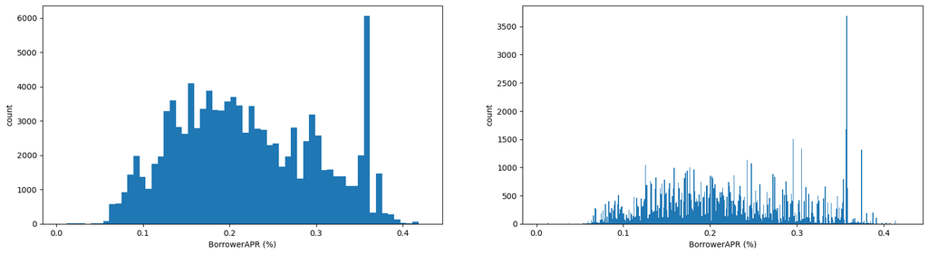

```python
# Create a histogram to show the distribution of Borrower's APR
plt.figure(figsize=[20,5])
plt.subplot(1,2,1)
bins = np.arange(0.005, new_df['BorrowerAPR'].max()+0.007, 0.007)
plt.hist(data= new_df, x='BorrowerAPR', bins = bins)
plt.xlabel('BorrowerAPR (%)')
plt.ylabel('count')

plt.subplot(1,2,2)
bins = np.arange(0.005, new_df['BorrowerAPR'].max()+0.001, 0.001)
plt.hist(data= new_df, x='BorrowerAPR', bins = bins)
plt.xlabel('BorrowerAPR (%)')
plt.ylabel('count')
plt.show();
```

From the above distribution, it is observed that the BorrowerAPR has a trimodal distribution between the regions of 0.15-0.2, 0.3 and within 0.35 and 0.4. The rest of the distribution is evenly distributed when both charts are compared except in the regions. Further investigation will showcase more clearly the distribution when compared with other variables.

Now lets take a look at the distribution of borrower interest rate and see if there is a similar pattern with the BorrowerAPR above.

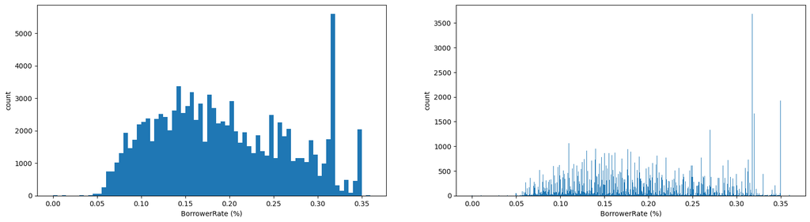

```python
# Create a histogram to showcase the distribution of Borrower Interest Rate for the loan
plt.figure(figsize=[20,5])
plt.subplot(1,2,1)
bins = np.arange(0, new_df['BorrowerRate'].max()+0.005, 0.005)
plt.hist(data=new_df, x='BorrowerRate', bins = bins)
plt.xlabel('BorrowerRate (%)')
plt.ylabel('count')

plt.subplot(1,2,2)
bins = np.arange(0, new_df['BorrowerRate'].max()+0.0005, 0.0005)
plt.hist(data=new_df, x='BorrowerRate', bins = bins)
plt.xlabel('BorrowerRate (%)')
plt.ylabel('count');
```

The distribution of the borrower's interest rate follows a similar pattern with the distribution of the borrowerAPR with a unimodal distribution coupled with multimodal

Now, let us see the distribution for our third variable of interest which is the LoanOriginalAmount

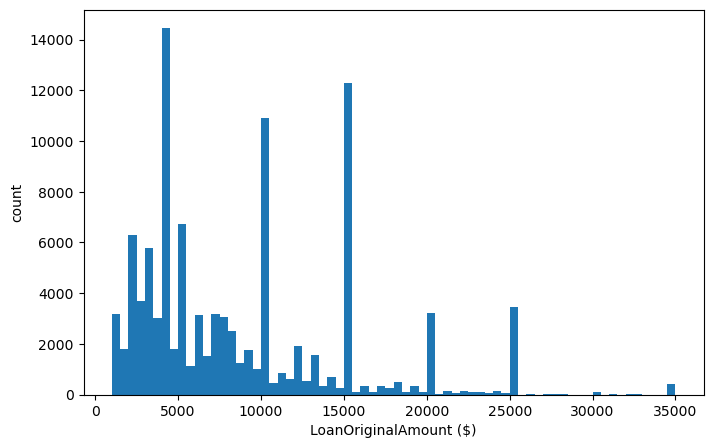

```python
#Create a histogram to show the distribution of loan original amount
plt.figure(figsize=[8,5])
bins = np.arange(1000, new_df['LoanOriginalAmount'].max()+500, 500)
plt.hist(data=new_df, x='LoanOriginalAmount', bins = bins)
plt.xlabel('LoanOriginalAmount ($)')
plt.ylabel('count')
plt.show();
```

The distribution for the loan original amount is of a multimodal distribution with various peak variations at different price regions. However, there are outliers at the end of the distributin in the 28000 - 35000 range which depicts that a very low amount of persons where granted huge amount of loans as compared to the lower range of 15000 and below where more loan amount were granted.

We can now ascertain the distribution of the fourth variable of interest - LoanStatus. We would try to ascertain the proportion of borrowers attitude towards repayment of loans as at when due.

```python
# Creating a function that creates a bar chart for a univariate categorical variable to avoid creating repetitive barchart codes.

def barchart(i):
    color=sns.color_palette()[0]
    sns.countplot(data = new_df, x= i, color=color);
def barcharty(i):
    color=sns.color_palette()[0]
    sns.countplot(data = new_df, y= i, color=color);
```

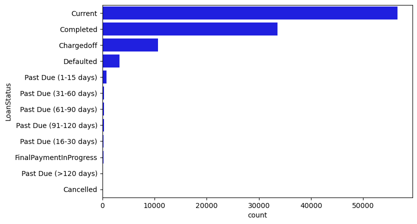

```python
# Create a bar chart for the Loan Status
plt.figure(figsize=[8,5])
order = new_df.LoanStatus.value_counts().index
sns.countplot(data= new_df, y = 'LoanStatus', order=order, color='blue');
```

```python
new_df.LoanStatus.value_counts()
```

```
Current                   56566
Completed                 33548
Chargedoff                10634
Defaulted                  3291
Past Due (1-15 days)        806
Past Due (31-60 days)       363
Past Due (61-90 days)       313
Past Due (91-120 days)      304
Past Due (16-30 days)       265
FinalPaymentInProgress      205
Past Due (>120 days)         16
Cancelled                     1
Name: LoanStatus, dtype: int64
```

Next is the first predictor variable which is the Term of the loan in months. A barchart would be plotted to month the distribution in months for the loan periods(term).

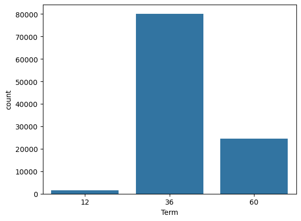

```python
# Using seaborn's countplot function to plot a bar chart for the loan Term
barchart('Term');
```

```python
# lets see the count per loan Term
new_df.Term.value_counts()
```

```
36    80155
60    24543
12     1614
Name: Term, dtype: int64
```

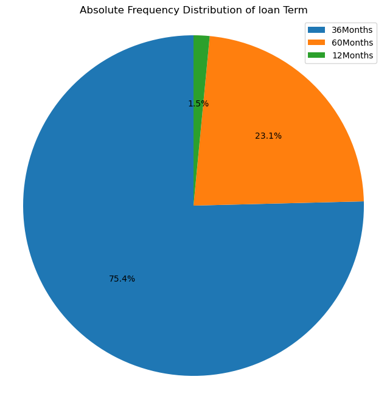

```python
# Create a pie chart to show distribution
plt.figure(figsize=[8,8])
c = new_df.Term.value_counts()
labels = '36Months','60Months','12Months'
plt.pie(c, autopct='%1.1f%%', startangle=90)
plt.title('Absolute Frequency Distribution of loan Term')
plt.axis('square')
plt.legend(labels);
```

From the distibution above, it is seen that a higher proportion of Prosper loans were approved for a 36 months period while a lesser proportion were approved for a 60 month period with a very small proportion of loans approved for a 12 months period. Now we can therefore ask the question of what type of loans were approved for the 36 months period as against loans approved for both 60 and 12 months respectively.

Moving forward, let's look at the 2nd predictor variable which is the distribution for the loan listing categories to see which listing category got the highest proportion of loans.

```python
# Creating a function that creates a bar chart for a univariate categorical variable.

def barchart(i):
    color=sns.color_palette()[0]
    sns.countplot(data = new_df, x= i, color=color);
def barcharty(i):
    color=sns.color_palette()[0]
    sns.countplot(data = new_df, y= i, color=color);
```

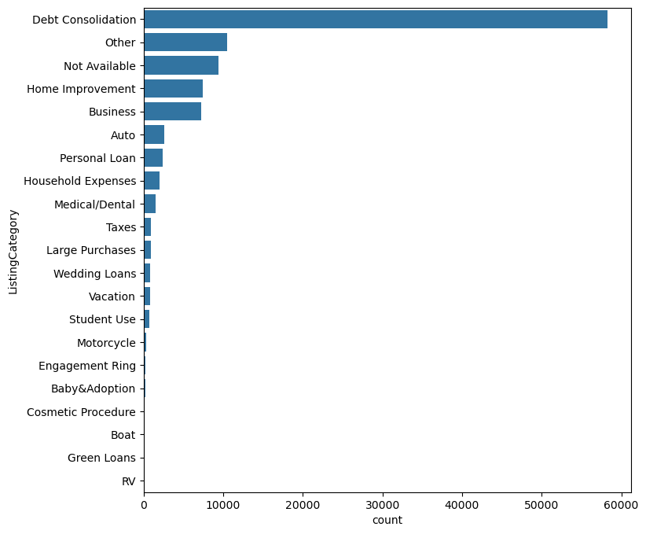

```python
# create a bar chart ordered from the highest count to the lowest.
plt.figure(figsize=[8,8])
cat = new_df.ListingCategory.value_counts().index
sns.countplot(data = new_df, y = 'ListingCategory', color=sns.color_palette()[0], order = cat);
```

```python
new_df.ListingCategory.value_counts()
```

```
Debt Consolidation    58293
Other                 10491
Not Available          9363
Home Improvement       7432
Business               7187
Auto                   2572
Personal Loan          2395
Household Expenses     1995
Medical/Dental         1522
Taxes                   885
Large Purchases         876
Wedding Loans           770
Vacation                768
Student Use             756
Motorcycle              304
Engagement Ring         217
Baby&Adoption           199
Cosmetic Procedure       91
Boat                     85
Green Loans              59
RV                       52
Name: ListingCategory, dtype: int64
```

The ListCategory has the distribution of Debt Consolidation as the most listing or better still the most reason for loans applied for at Prosper with RV showing as the least reason for a loan application. This knowledge is central to our analysis as a comparison can then be made with the loan Term and other variables to ascertain the differences between loans depending on the size of loans obtained.

Let's look at the third predictor variable of IncomeRange to see the distribution of Prosper loans across the different Income ranges of its applicants/borrowers.

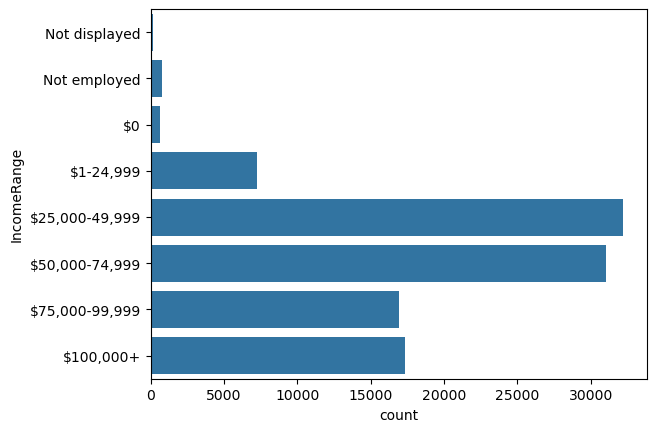

```python
# Create a bar chart for IncomeRange with our barcharty function created.
barcharty('IncomeRange')
```

A careful look at the incomeRange distribution shows clearly that borrowers with an income range of 25,000 to 74,999 dollars had the highest rate of loans obtained from Prosper. We can also see that even borrowers that earned no income as well as borrowers that aren't employed got loans albeit a very small proportion of borrowers within that category. We will explore our data further to ascertain the original loan amount that are prevalent within these income ranges and gain a valuable insight from that distribution to help answer our research question.

From the variable description, we can confirm that the above income ranges are yearly income ranges since the data provided a value for their monthly income and when compared to this value shows it's the yearly income.

we will now take a look at the fourth predictor variable which is the borrower's employment status to know if more employed persons got more loans over the unemployed and other categories, and what proportion of employed persons got loans over the umemployed. Although, it is quite obvious that more employed persons will access loans in comparison to their unemployed counterparts. The question we will be diving into from our distribution is to know the size of loans that these categories of earners could access. But before we can ascertain that information, firstly let's look at the distribution across the employemnt status categories.

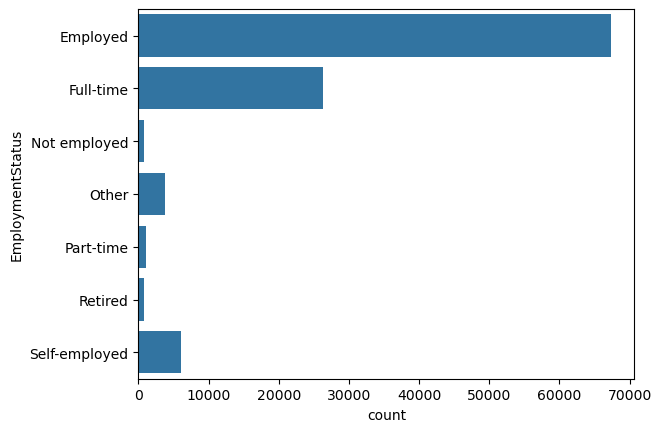

```python
# Create a bar chart using barchart function for EmploymentStatus
barcharty('EmploymentStatus')
```

A random guess would have easily predicted that more employed persons would get loans over those not employed, retired, working part-time and other forms of employment without a fixed income. This is self evident as seen in the distribution of Employment status above. This distribution however, can help to answer the question of size of loans offered to the unemployed, retired, part-time borrowers in comparison with the employed, full-time, and self-employed borrowers.

The fifth predictor variable is to know which categories of borrowers are home owners and those who are not. Is this factor responsible for obtaining loans ? and to what extent does it affect obtaining loans?

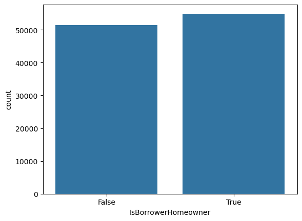

```python
# Create a barchart for IsBorrowerHomeOwner using the barchart function we created
barchart('IsBorrowerHomeowner')
```

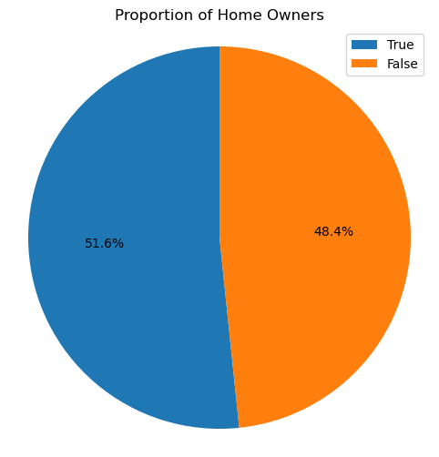

```python
# Creating a pie chart to assess the proportion of home owners
plt.figure(figsize=[8,6])
count = new_df.IsBorrowerHomeowner.value_counts()
labels=count.index
plt.pie(count, autopct='%1.1f%%', startangle=90)
plt.axis('square')
plt.title('Proportion of Home Owners')
plt.legend(labels);
```

```python
# First let us create two extra columns for loan origination month and year
new_df['LoanOriginationYear'] = new_df['LoanOriginationDate'].dt.year
new_df['LoanOriginationMonth'] = new_df['LoanOriginationDate'].dt.month
```

```python
# Set the order of the LoanOriginationQuarter categorical variable
cat = ['Q1 2007', 'Q2 2007', 'Q3 2007', 'Q4 2007', 'Q1 2008', 'Q2 2008', 'Q3 2008', 'Q4 2008',
       'Q1 2009', 'Q2 2009', 'Q3 2009', 'Q4 2009', 'Q1 2010', 'Q2 2010', 'Q3 2010', 'Q4 2010',
       'Q1 2011', 'Q2 2011', 'Q3 2011', 'Q4 2011', 'Q1 2012', 'Q2 2012', 'Q3 2012', 'Q4 2012',
       'Q1 2013', 'Q2 2013', 'Q3 2013', 'Q4 2013', 'Q1 2014']
ord_cat = CategoricalDtype(categories=cat, ordered=True)
new_df.LoanOriginationQuarter = new_df.LoanOriginationQuarter.astype(ord_cat)
```

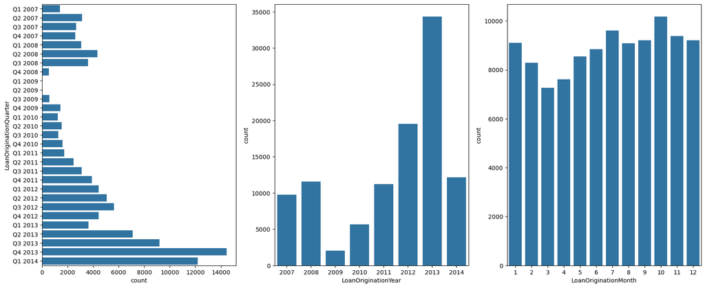

```python
# Create a subplot for loan origination quarter, year and month to compare the distribution
plt.figure(figsize=[20,8])
plt.subplot(1,3,1)
barcharty('LoanOriginationQuarter')

plt.subplot(1,3,2)
barchart('LoanOriginationYear')

plt.subplot(1,3,3)
barchart('LoanOriginationMonth')
plt.show();
```

```python
new_df['LoanOriginationYear'].value_counts()
```

```
2013    34337
2012    19549
2014    12172
2008    11548
2011    11228
2007     9786
2010     5645
2009     2047
Name: LoanOriginationYear, dtype: int64
```

### Discuss the distribution(s) of your variable(s) of interest. Were there any unusual points? Did you need to perform any transformations?

For the BorrowerAPR, a trimodal distribution was observed across different peak positions with a sharp peak being observed between the regions of 0.3 and 0.4. The same distribution pattern was also observed in the BorrowerRate plot even though a closer look at its distribution shows more of a bimodal distribution around the regions of 0.3 and 0.35.

The LoanOriginalAmount however, shows a multimodal distribution with very low proportion of loans (outliers observed) given out within the price range of 30,000-35000 dollars, while majority of loans given out fell within the lower price range of 15,000 and below. Also, we noticed that a huge amount of loan has their status has completed and a very low amount of loans has their status has `PastDue` or `Defaulted`.Therefore, our analysis will attempt to look at the factors that could have affected the outcome of the loanStatus - `PastDue`, `Completed` and `Defaulted`.

### Of the features you investigated, were there any unusual distributions? Did you perform any operations on the data to tidy, adjust, or change the form of the data? If so, why did you do this?

It was observed that very little proportion of loans (1.5%) were given out for a 12 month Term with Debt consolidation topping the charts as the major reason that borrowers obtained loans. It was also observed that employed persons obtained more loans within the period compared to other categories of borrowers. Also, an unusual distribution was observed in the year 2009 in comparison with other years as a very small proportion of loans were administered in that year. More investigation will be needed to find out why. The year 2013 however, had high proportion of loans administered when compared with other years.

Certain adjustment were made on the loan data to obtained clarity of the loan origination period - two new variables were created for LoanOriginationYear and LoanOriginationMonth whilst the order of the LoanOriginationQuarter was adjusted to get the right quarterly ordered categories from 1st quarter of 2007 to the 1st quarter of 2014

## Bivariate Exploration

> In this section, investigate relationships between pairs of variables in your data. Make sure the variables that you cover here have been introduced in some fashion in the previous section (univariate exploration).

First let's look at the effect of other factors on Borrower's APR and BorrowerRate

```python
num_vars = ['Term','BorrowerAPR','BorrowerRate','LenderYield','LoanOriginalAmount','StatedMonthlyIncome','MonthlyLoanPayment','EmploymentStatusDuration']
cat_vars = ['Listingcategory','IncomeRange','IsBorrowerHomeOwner','LoanOriginationYear','LoanOriginationQuarter']
```

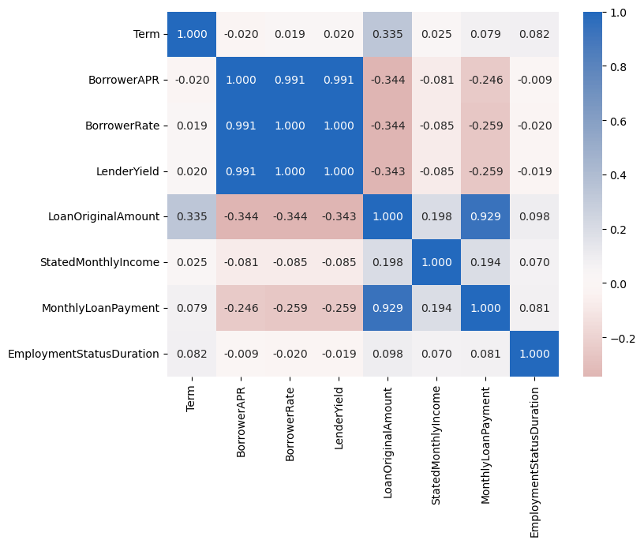

```python
# correlation plot
plt.figure(figsize = [8, 6])
sns.heatmap(new_df[num_vars].corr(), annot = True, fmt = '.3f',
           cmap = 'vlag_r', center = 0)
plt.show()
```

```python
# Choose 500 random observations from the loan dataset
np.random.seed(1)
loan_sample = new_df.sample(500)
```

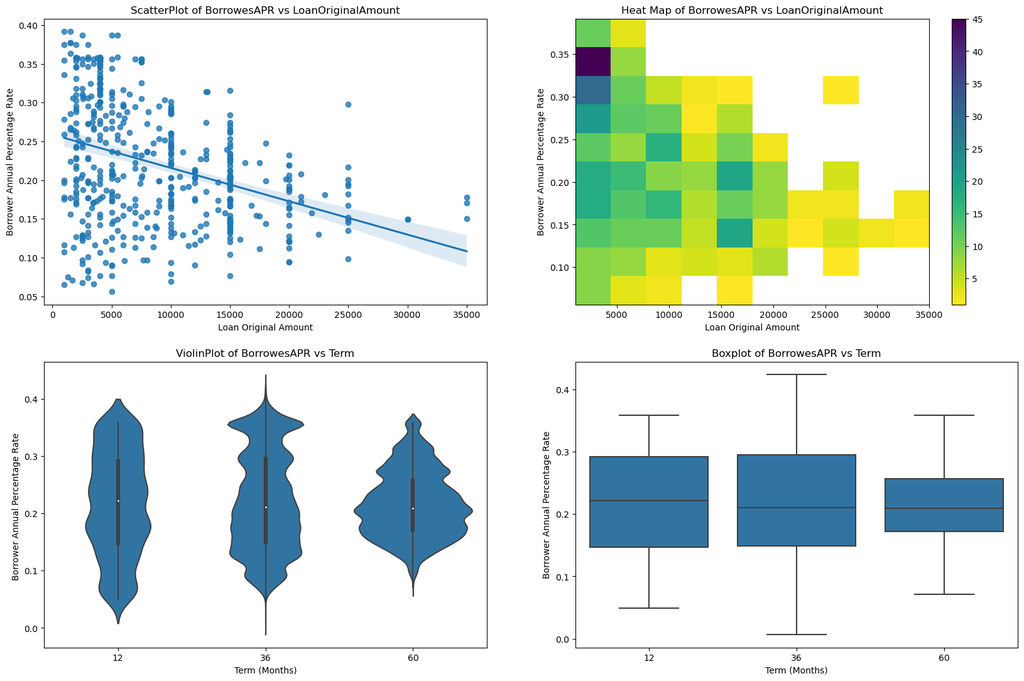

```python
# Create a subplot for LoanOriginal Amount and Term
plt.figure(figsize=[20,13])

plt.subplot(2,2,1)
sns.regplot(data=loan_sample, y='BorrowerAPR', x='LoanOriginalAmount') #creating a scatter plot using seaborn
plt.ylabel('Borrower Annual Percentage Rate')
plt.xlabel('Loan Original Amount')
plt.title('ScatterPlot of BorrowesAPR vs LoanOriginalAmount');

plt.subplot(2,2,2)
plt.hist2d(data=loan_sample,  y='BorrowerAPR', x='LoanOriginalAmount', cmap='viridis_r', cmin=0.5) #creating a heatmap
plt.ylabel('Borrower Annual Percentage Rate')
plt.xlabel('Loan Original Amount')
plt.title('Heat Map of BorrowesAPR vs LoanOriginalAmount');
plt.colorbar();

plt.subplot(2,2,3)
sns.violinplot(data=new_df, y='BorrowerAPR', x='Term',color=sns.color_palette()[0]) #creating a violin plot for loan Term
plt.ylabel('Borrower Annual Percentage Rate ')
plt.xlabel('Term (Months)')
plt.title('ViolinPlot of BorrowesAPR vs Term');

plt.subplot(2,2,4)
sns.boxplot(data=new_df,  y='BorrowerAPR', x='Term', color=sns.color_palette()[0]) #creating a boxplot for loan Term
plt.ylabel('Borrower Annual Percentage Rate')
plt.xlabel('Term (Months)')
plt.title('Boxplot of BorrowesAPR vs Term');
```

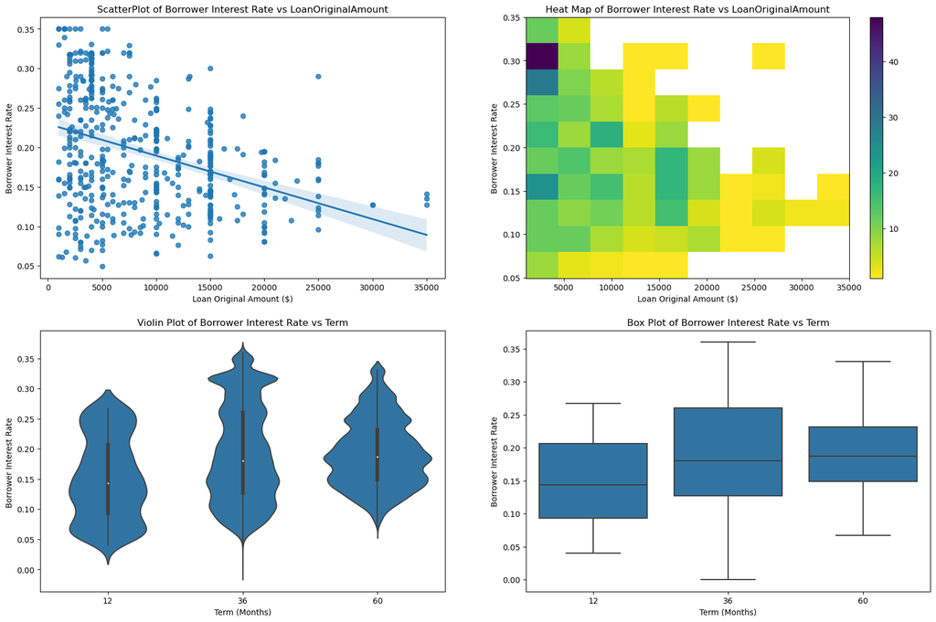

```python
plt.figure(figsize=[20,13])

plt.subplot(2,2,1)
sns.regplot(data=loan_sample, y='BorrowerRate', x='LoanOriginalAmount')
plt.ylabel('Borrower Interest Rate')
plt.xlabel('Loan Original Amount ($)')
plt.title('ScatterPlot of Borrower Interest Rate vs LoanOriginalAmount');

plt.subplot(2,2,2)
plt.hist2d(data=loan_sample,  y='BorrowerRate', x='LoanOriginalAmount', cmap='viridis_r', cmin=0.5)
plt.ylabel('Borrower Interest Rate')
plt.xlabel('Loan Original Amount ($)')
plt.title('Heat Map of Borrower Interest Rate vs LoanOriginalAmount');
plt.colorbar();

plt.subplot(2,2,3)
sns.violinplot(data=new_df, y='BorrowerRate', x='Term',color=sns.color_palette()[0])
plt.ylabel('Borrower Interest Rate ')
plt.xlabel('Term (Months)')
plt.title('Violin Plot of Borrower Interest Rate vs Term');

plt.subplot(2,2,4)
sns.boxplot(data=new_df,  y='BorrowerRate', x='Term',color=sns.color_palette()[0])
plt.ylabel('Borrower Interest Rate')
plt.xlabel('Term (Months)')
plt.title('Box Plot of Borrower Interest Rate vs Term');
```

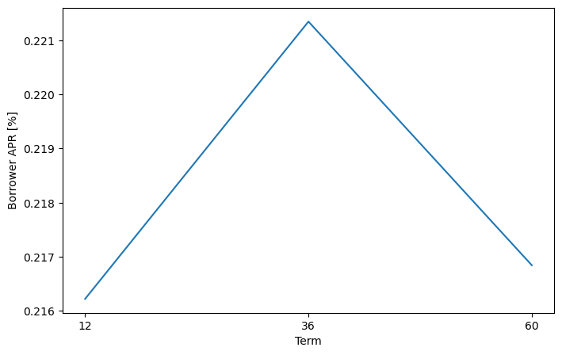

```python
plt.figure(figsize=[8,5])
plt.plot(new_df.groupby('Term')['BorrowerAPR'].mean())
plt.xlabel('Term')
plt.ylabel('Borrower APR [%]')
plt.xticks([12,36,60])
plt.show();
```

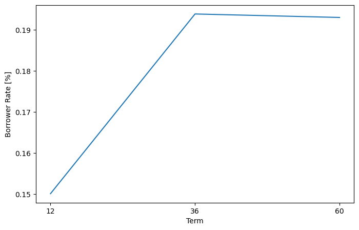

```python
plt.figure(figsize=[8,5])
plt.plot(new_df.groupby('Term')['BorrowerRate'].mean())
plt.xlabel('Term')
plt.ylabel('Borrower Rate [%]')
plt.xticks([12,36,60])
plt.show();
```

From the correlation map and the relationship shown on both the heatmap and scatter plot, a negative correlation clearly exists between the BorrowerAPR and the LoanOriginalAmount and also the Borrower Interest Rate vs Loan Original Amount. Loan original amounts greater than $20,000 are much more prone to have lower Borrower APR and Borrower Interest Rate compared to lesser amount of $10,000 and below which are more likely to have higher Borrower APR and Borrower Interest Rate. Thus, there is clearly a negative correlation albeit a weak one.

lets look at if there are difference between loans based on the size of the loan original amount

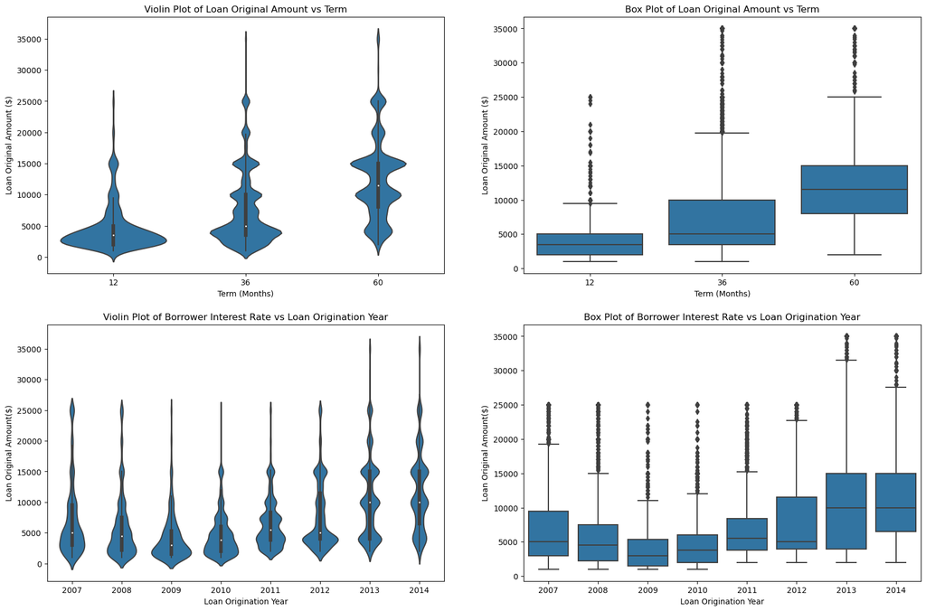

```python
# Creating a subplot of violin and boxplots for LoanOriginalAmount vs Term
plt.figure(figsize=[20,13])
color=sns.color_palette()[0]
plt.subplot(2,2,1)
sns.violinplot(data=new_df, y='LoanOriginalAmount', x='Term', color=color)
plt.ylabel('Loan Original Amount ($)')
plt.xlabel('Term (Months)')
plt.title('Violin Plot of Loan Original Amount vs Term');

plt.subplot(2,2,2)
sns.boxplot(data=new_df,  y='LoanOriginalAmount', x='Term', color=color)
plt.ylabel('Loan Original Amount ($)')
plt.xlabel('Term (Months)')
plt.title('Box Plot of Loan Original Amount vs Term')


plt.subplot(2,2,3)
sns.violinplot(data=new_df, y='LoanOriginalAmount', x='LoanOriginationYear', color=color)
plt.ylabel('Loan Original Amount($)')
plt.xlabel('Loan Origination Year')
plt.title('Violin Plot of Borrower Interest Rate vs Loan Origination Year')

plt.subplot(2,2,4)
sns.boxplot(data=new_df, y='LoanOriginalAmount', x='LoanOriginationYear', color=color)
plt.ylabel('Loan Original Amount($)')
plt.xlabel('Loan Origination Year')
plt.title('Box Plot of Borrower Interest Rate vs Loan Origination Year')
plt.show();
```

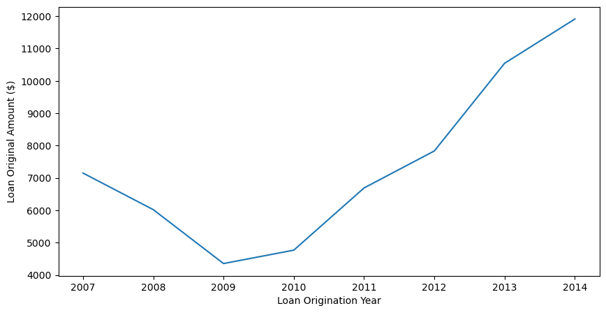

```python
#Line plot for the average loan original amount vs Loan Origination Year
plt.figure(figsize=[10,5])
plt.plot(new_df.groupby('LoanOriginationYear')['LoanOriginalAmount'].mean())
plt.xlabel('Loan Origination Year')
plt.ylabel('Loan Original Amount ($)')
plt.show();
```

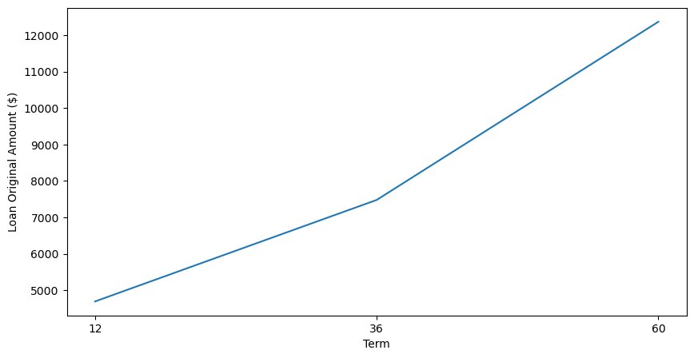

```python
plt.figure(figsize=[10,5])
plt.plot(new_df.groupby('Term')['LoanOriginalAmount'].mean())
plt.xlabel('Term')
plt.ylabel('Loan Original Amount ($)')
plt.xticks([12,36,60])
plt.show();
```

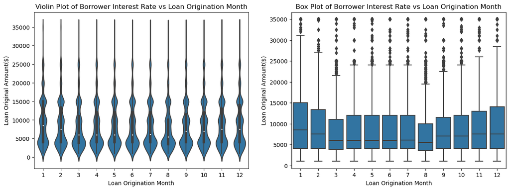

```python
#Craeting violin and box plot for loan orgination amount and loan origination month
plt.figure(figsize=[15,5])
plt.subplot(1,2,1)
sns.violinplot(data=new_df, y='LoanOriginalAmount', x='LoanOriginationMonth', color=color)
plt.ylabel('Loan Original Amount($)')
plt.xlabel('Loan Origination Month')
plt.title('Violin Plot of Borrower Interest Rate vs Loan Origination Month')

plt.subplot(1,2,2)
sns.boxplot(data=new_df, y='LoanOriginalAmount', x='LoanOriginationMonth', color=color)
plt.ylabel('Loan Original Amount($)')
plt.xlabel('Loan Origination Month')
plt.title('Box Plot of Borrower Interest Rate vs Loan Origination Month')
plt.show();
```

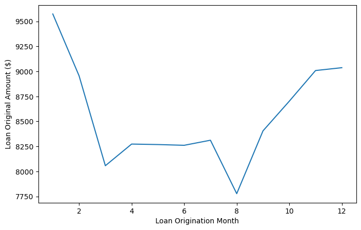

```python
# Craeting a line pot for Loan Original amount VS Origination Month
plt.figure(figsize=[8,5]) # sets the figure size
plt.plot(new_df.groupby('LoanOriginationMonth')['LoanOriginalAmount'].mean())
plt.xlabel('Loan Origination Month') # x axis label
plt.ylabel('Loan Original Amount ($)') # y axis label
plt.show();
```

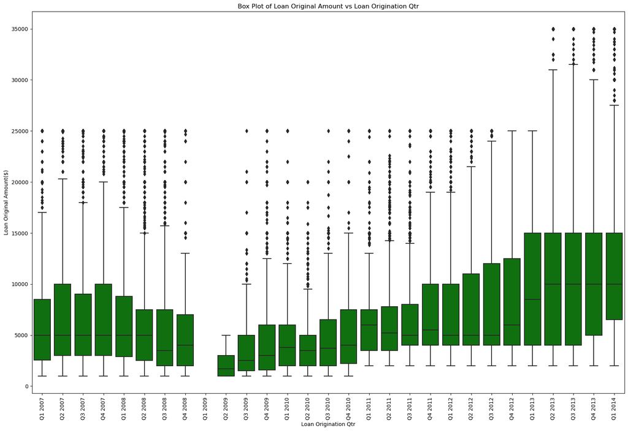

```python
# Creating a box pot for Loan Original amount VS Origination Quarter
plt.figure(figsize=[20,13])
sns.boxplot(data=new_df, y='LoanOriginalAmount', x='LoanOriginationQuarter', color='green')
plt.ylabel('Loan Original Amount($)')
plt.xlabel('Loan Origination Qtr')
plt.title('Box Plot of Loan Original Amount vs Loan Origination Qtr')
plt.xticks(rotation=90)
plt.show();
```

From the insights garnered in the plot of loan original amount with other variables, it was observed that larger loan original amounts of $12,000 and above would likely have a 60 month loan Term , while loan amounts of $7,500 on average would have a 36 month Term, with lesser amounts of $5,000 and below having a 12 month loan Term period to run.

Also, there is no way to tell from the plots why 2009 has such low rate of loans issued out except that in Q1 of 2009, no loans were isuued which may be attributed to the company - Prosper been shut down within the period due to certain reasons. Loans only started being issued in Q2 of 2009 and rose steadily till Q4 same year.

lets look at the difference in relation of Income range and Employment status when compared to the size of original loan

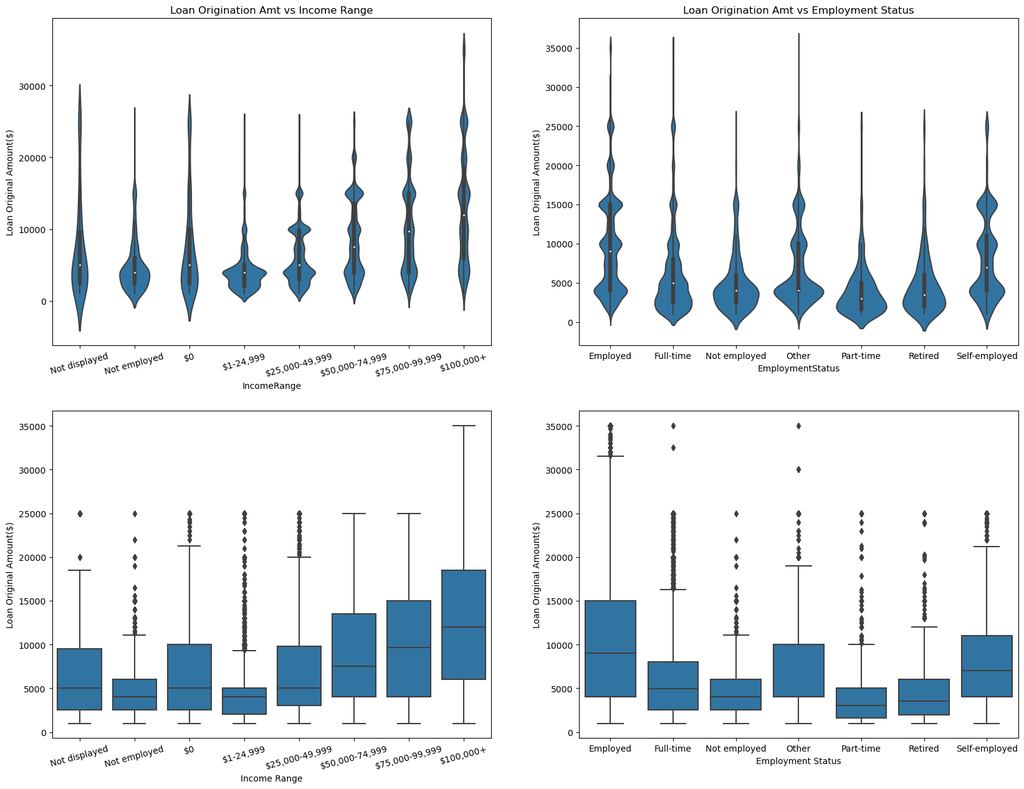

```python
#Creating 4 subplots of violinplot and boxplot for loan amount vs income range/employment status
plt.figure(figsize=[20,15])
color=sns.color_palette()[0]
plt.subplot(2,2,1)
sns.violinplot(data=new_df, y='LoanOriginalAmount', x='IncomeRange', color=color) #create violinplot using seaborn
plt.ylabel('Loan Original Amount($)')
# plt.xlabel('Income Range')
plt.title('Loan Origination Amt vs Income Range')
plt.xticks(rotation=15);

plt.subplot(2,2,2)
sns.violinplot(data=new_df, y='LoanOriginalAmount', x='EmploymentStatus', color=color)  #create violinplot using seaborn
plt.ylabel('Loan Original Amount($)')
# plt.xlabel('Employment status')
plt.title('Loan Origination Amt vs Employment Status');

plt.subplot(2,2,3)
sns.boxplot(data=new_df, y='LoanOriginalAmount', x='IncomeRange', color=color)  #create boxplot using seaborn
plt.ylabel('Loan Original Amount($)')
plt.xlabel('Income Range')
# plt.title('Loan Origination Amt vs Income Range')
plt.xticks(rotation=15);

plt.subplot(2,2,4)
sns.boxplot(data=new_df, y='LoanOriginalAmount', x='EmploymentStatus', color=color) #create boxplot using seaborn
plt.ylabel('Loan Original Amount($)')
plt.xlabel('Employment Status');
# plt.title('Loan Origination Amt vs Employment Status');
```

```python
new_df.groupby('IncomeRange')['LoanOriginalAmount'].mean()
```

```
IncomeRange
Not displayed      7208.985612
Not employed       4882.822360
$0                 7410.930757
$1-24,999          4274.599147
$25,000-49,999     6178.294814
$50,000-74,999     8675.889479
$75,000-99,999    10365.375783
$100,000+         13072.880351
Name: LoanOriginalAmount, dtype: float64
```

Borrowers with an income range of $0 as at the time of loan listing also had considerable access to loans albeit of smaller size averaging $7410. Not employed borrowers also had access to loans of smaller sizes of $5,000 on average. Lower income earners between the range of $1-$25,000 had access to the smallest size of loans averaging $4200. High income earners of between $25,000-$100,000+ obviously got access to larger sizes of loans.

In regards of employement status, it is quite related with the income range as employed borrowers accessed higher sizes of loans while part-time and not employed borrowers accessed the smallest sizes of loans

Lastly lets look at the factors affecting the loan's outcome status

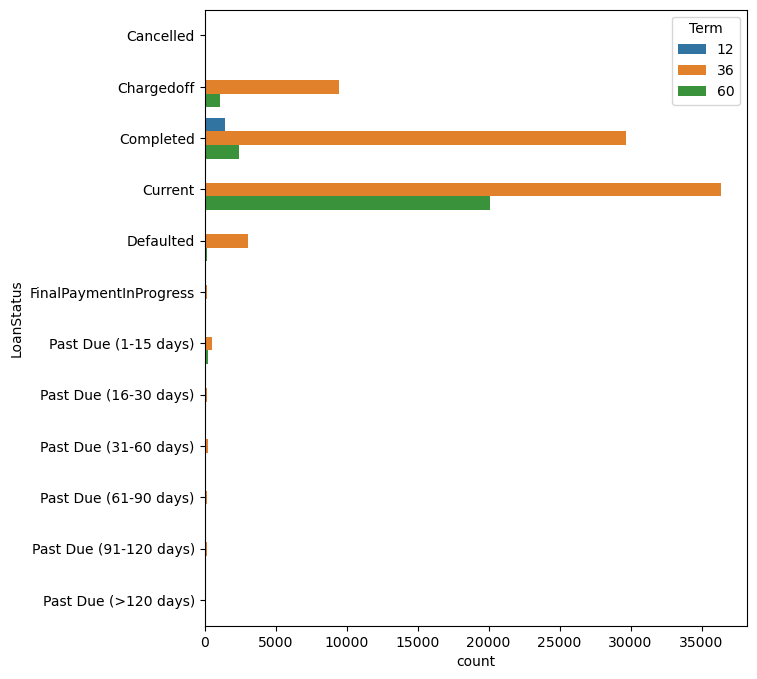

```python
#Creating a clustered bar chart to demonstrate relationship btw loan status vs Term
plt.figure(figsize=[7,8])
sns.countplot(data=new_df, y='LoanStatus', hue='Term'); #clustered bar chart using seaborn with qualitative variables
```

We earlier mentioned that our focus from the loan status will be on completed, defaulted,finalpaymentInProgress and past due. From the above distribution, loan status in completed category have higher counts of its completed loan status in the 36 month Term and lowest in 12 month Term. Defaulted borrowers fall majorly in the 36 month Term while the total accumulation of borrowers with a Past Due status are within the 36 month Term. FinalPaymentInProgress has no noticeable Term period as seen from the plot above.

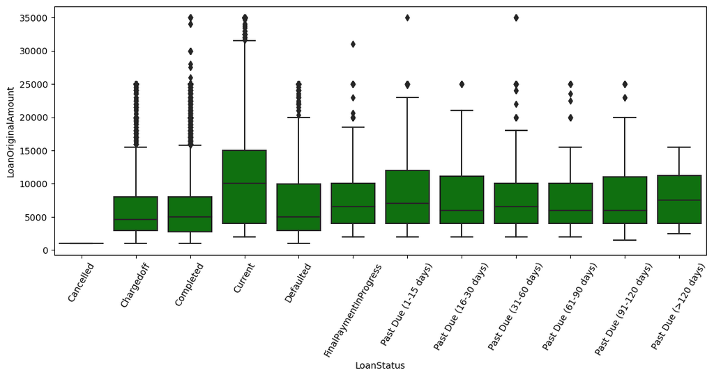

```python
#Creating a clustered bar chart to demonstrate relationship btw loan status vs Loan Original amt
plt.figure(figsize=[13,5])
sns.boxplot(data=new_df, x='LoanStatus', y='LoanOriginalAmount', color='green') #box plot using seaborn
plt.xticks(rotation=60); #rotate x labels by 90deg.
```

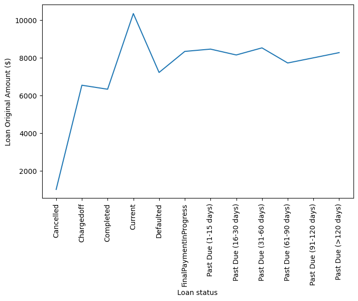

```python
# Creating a line plot with average loan original amounts for loan status
plt.figure(figsize=[8,5]) # sets the figure size
plt.plot(new_df.groupby('LoanStatus')['LoanOriginalAmount'].mean())
plt.xlabel('Loan status') # x axis label
plt.ylabel('Loan Original Amount ($)') # y axis label
plt.xticks(rotation=90)
plt.show();
```

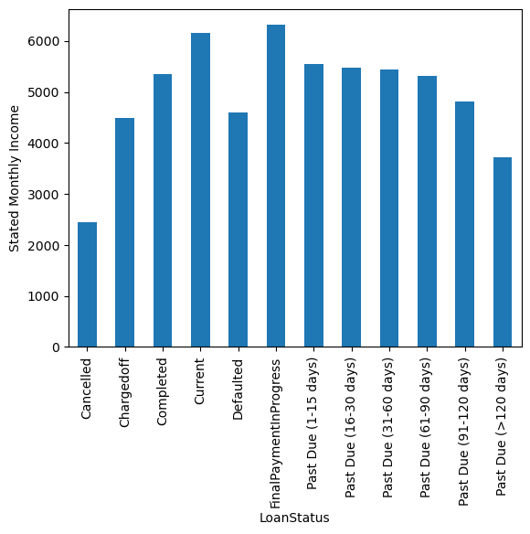

```python
new_df.groupby('LoanStatus')['StatedMonthlyIncome'].mean().plot(kind='bar', ylabel='Stated Monthly Income')
```

Lets look at a bivariate plot for two predictor variable - IncomeRange and EmploymentStatus to ascertain if those in the $0 are employed or not

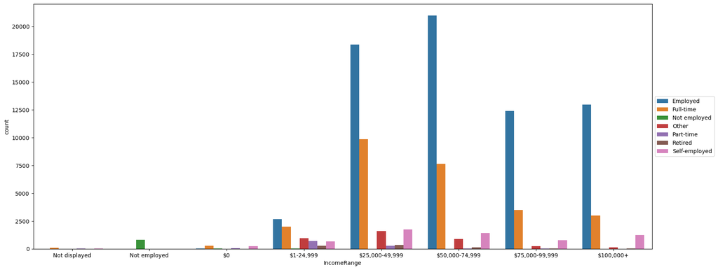

```python
#Creating a faced grid of boxplots for multivariate variables of loan status, IncomeRange and MonthlyloanPayments
plt.figure(figsize=[20,8])
sns.countplot(data = new_df, x = 'IncomeRange', hue = 'EmploymentStatus')
plt.legend(loc = 6, bbox_to_anchor = (1.0, 0.5)); # legend to right of figure
```

Those in the $0 income range majorly work full-time, part-time or are self-employed. This could be interpreted to mean that these categories of borrowers either do not have a fixed income range that is declarable or they provided a wrong data on their income.

### Talk about some of the relationships you observed in this part of the investigation. How did the feature(s) of interest vary with other features in the dataset?

For the BorrowerAPR/BorrowerInterest feature, a 36 & 60 month Term will likely have a higher BorrowerInterest rate than a loan with Term of 12 months.Alternatively, Term of loan will have no considerable effect on the BorrowerAPR rate.

With respect to the loanOriginalAmount obtained by borrowers, loan amount of less than $10,000 will have higher BorrowerAPR and BorrowerInterest rate while loan amounts of greater than $20,000 will have lower BorrowerAPR/BorrowerInterest rates.

Interestingly, it was observed that borrowers of $0 income range had access to higher sizes of loans than borrowers in the income range of Not Employed and $1-$25,000 and also had access to same sizes of loans with those within the IncomeRange of $25,000-$50,000. Borrower with the income range of $25,000-100,000+ had access to the highest sizes of loans. Also, Employment status had an effect on LoanOriginalAmount obtained as employed borrowed access higher loans than the not employed/part-time borrowers.

For the LoanStatus outcome feature, a 36 month Term was observed to be prevalent as the majority Term in the Completed, Defaulted, FinalPaymentInProgress and PastDue categories of loan statuses

With respect to the LoanOriginalAmount, completed loan status accessed the lowest sizes of loans (averaging $6000) while current loan status had access to the highest sizes of loans (averaging $10,500), all the categories of Past Due & Defaulted loan statuses showed no considerable difference in the original loan amount accessed

### Did you observe any interesting relationships between the other features (not the main feature(s) of interest)?

2009 had a very low proportion of loans issued out to borrowers and on a more careful analysis, it was observed that Q1 of 2009 had no loan amount issued indicative on no business activity whatsoever. Q2 od same year have a very meagre amount of loans issued which then picked up gradually in Q3 and Q4 of same year

It was also discovered that the $0 income range earners work full-time, part-time or self-employed. This is an interesting observation that explains why they could access same sizes of loans as those in the $25,000-$50,000 income range bracket.

## Conclusions

The Prosper loan dataset provided a large amount of variables when downloaded which was wrangled for the purpose of this analysis into seventeen(17) variables. We went further to carry out some data wrangling including data cleaning and data manipulation and in the course of this wrangling, two(2) additional variables were created - LoanOriginationMonth and LoanOriginationYear.

Three major questions guided the entire exploration and analysis of the loan dataset which are:

. What factors affects a loan's outcome status . What affects the borrower's APR or borrower interest rate . Are there differences between loans depending on how large the original loan amount was?

Based on these research questions, we identified FOUR(4) main variables of interest namely LoanStatus, BorrowerAPR, BorrowerInterest and LoanOriginalAmount. and some other predictor variables namely: Term, ListCategory, IncomeRange, StatedMonthlyIncome, EmploymentStatus, IsBorrowerHomeOwner, LoanOriginationQuarter, LoanOriginationMonth and LoanOriginationYear.

Loan Outcome status A loan outcome status is affected by a variety of factors such as the loan *Term* which is the length of the loan. The Term of the loan however is dependent on the *LoanOriginalAmount* as smaller loan amounts get smaller loan Terms and vice versa. It was observed that loan Term OF 12 months has a higher rate of being completed, as it was observed that most of the loan status on *PastDue* were majorly of Term 36 and 60 months. Another factor that affects the loan outcome status is the *LoanOriginalAmount. It was observed that higher loan amounts are more prone to have loan status of Defaulted, or PastDue* while lower loan amounts had a higher rate of been completed.

Loan Original Amount In ascertaining if there are differences between loans depending on the size of original loan, a couple of variables were checked.

Secondly, with respect to the *Term*, it was observed that higher sizes of loans are deemed to be longer Term loans than smaller sizes of LoanOriginalAmount. Larger loan original amounts of $12,000 and above would likely have a 60 month loan Term , while loan amounts of $7,500 on average would likely have a 36 month Term, with lesser amounts of $5,000 and below having a 12 month loan Term period to run.

Thirdly, with respect to the *BorrowerIncomeRange, borrowers with the income range of $50,000-100,000+ had access to the highest sizes of loans. More interestingly, it was also observed that borrowers of $0 income range had access to higher sizes of loans than borrowers in the income range of Not Employed* and $1-$25,000 and also had access to same sizes of loans with those within the IncomeRange of $25,000-$49,999. On a more deeper dive into why this could occur, we compared the IncomeRange with the EmploymentStatus and found out that borrowers of $0 income range within our data when accessed for their *EmploymentStatus* have patterns of *full-time, part-time* or *self-employed* employment statuses. This is an interesting observation that explains why they could access same sizes of loans as those in the $25,000-$49,999 income range bracket.

Furthermore, with respect to *EmploymentStatus*, it was observed that employed borrowers accessed higher loans sizes than the NotEmployed/part-time borrowers.

```python
#Saving the dataframe
new_df.to_csv('loan.csv')
```